# Data Analytics

Gokce Muge Cil & Can Aykul

27 Temmuz 2018

## Motivation / Idea / Question

In this project, we wanted to investigate wines. Our motivation is to understand insights of wine. To do this, we do not ask just one question and try to achieve an answer but ask multiple questions such as:  
* What does this dataset shows us in general?  
* Can we add new features to dataset? If so, how? Does it works?  
* Can we improve the existing features by filling the NA values in the data with linear regression? How to interpret the prediction results?  
* Lastly, how to cluster wines?

## Approach

Our approach is as follows:  
1. We will introduce the data and show some plots about it to get the first insight.  
2. We will try to add a new feature by doing naive Natural Language Processing and a more complicated one. Then we will test whether this new feature makes sense or not.  
3. We will fill the NA values after finding a nice correlation between existing features and the new feature that we add. After finding a nice correlation tuple then we will use this with inside linear regression. 4. We will cluster wines after improving dataset.

## Wine Reviews Dataset

URL: https://www.kaggle.com/zynicide/wine-reviews, file name: “winemag-data_first150k.csv” In this assignment, we used Wine Reviews dataset from Kaggle. It has 150 thousand reviews and their properties as below.

```
## 'data.frame':    150930 obs. of  11 variables:
##  $ X          : int  0 1 2 3 4 5 6 7 8 9 ...
##  $ country    : chr  "US" "Spain" "US" "US" ...
##  $ description: chr  "This tremendous 100% varietal wine hails from Oakville and was aged over three years in oak. Juicy red-cherry f"| __truncated__ "Ripe aromas of fig, blackberry and cassis are softened and sweetened by a slathering of oaky chocolate and vani"| __truncated__ "Mac Watson honors…
##  $ designation: chr  "Martha's Vineyard" "Carodorum Selección Especial Reserva" "Special Selected Late Harvest" "Reserve" ...
##  $ points     : int  96 96 96 96 95 95 95 95 95 95 ...
##  $ price      : num  235 110 90 65 66 73 65 110 65 60 ...
##  $ province   : chr  "California" "Northern Spain" "California" "Oregon" ...
##  $ region_1   : chr  "Napa Valley" "Toro" "Knights Valley" "Willamette Valley" ...
##  $ region_2   : chr  "Napa" "" "Sonoma" "Willamette Valley" ...
##  $ variety    : chr  "Cabernet Sauvignon" "Tinta de Toro" "Sauvignon Blanc" "Pinot Noir" ...
##  $ winery     : chr  "Heitz" "Bodega Carmen Rodríguez" "Macauley" "Ponzi" ...
```

#### Price & Country relationship investigation

Now lets start with plotting average wine prices for each country in the world map.

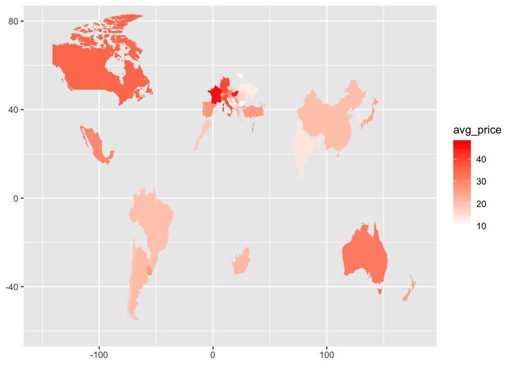

##### Another average price per country with geom_col:

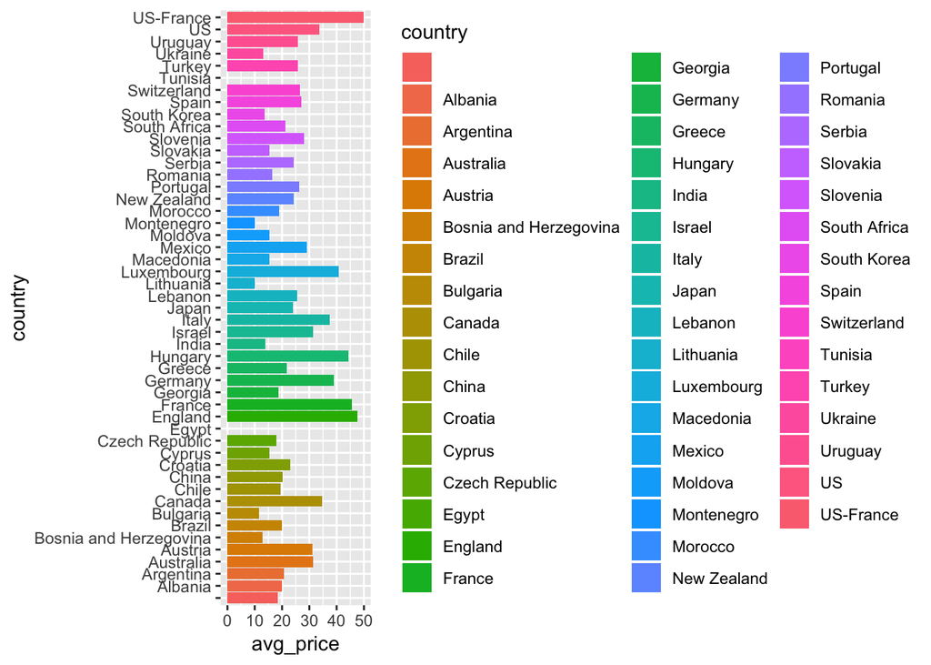

#### Points & Country Relationship

We now start to investigate points & country relationship in the dataset

##### Density graph for points - country each country separatetely

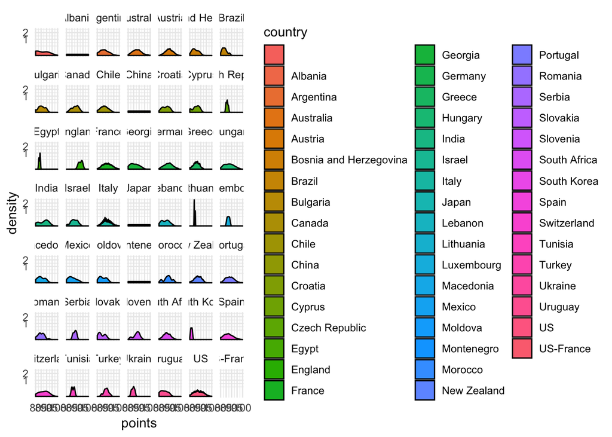

#### Now lets try to understand whether there is a dependency between price & points.

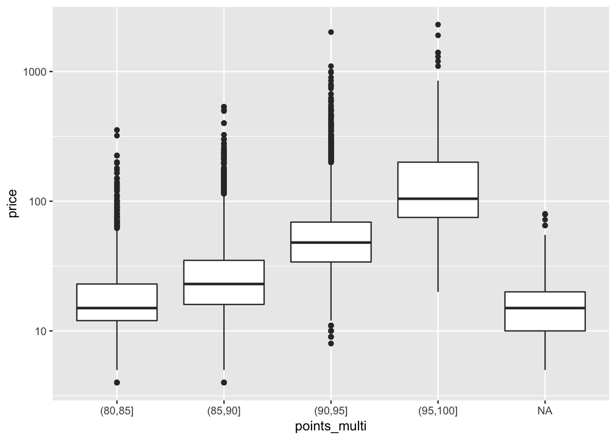

As we can see, low points range have less mean value of price. When the point range goes up to 95-100 points there we can claim that mean price of a wine is 100 and also there is more variation of prices in the upper side of mean which means, a wine which has 95-100 points can be really expensive.

### Improving the dataset by adding a feature with NLP

##### Naive approach

Our second part is adding a new feature to the dataset. We thought that we can use “description” column and make a naive hypothesis to find bad comments as “If a comment has word ‘bad’ in it, then it is likely that wine has a lower point.” Now lets look at what we achieve after we implemented it.

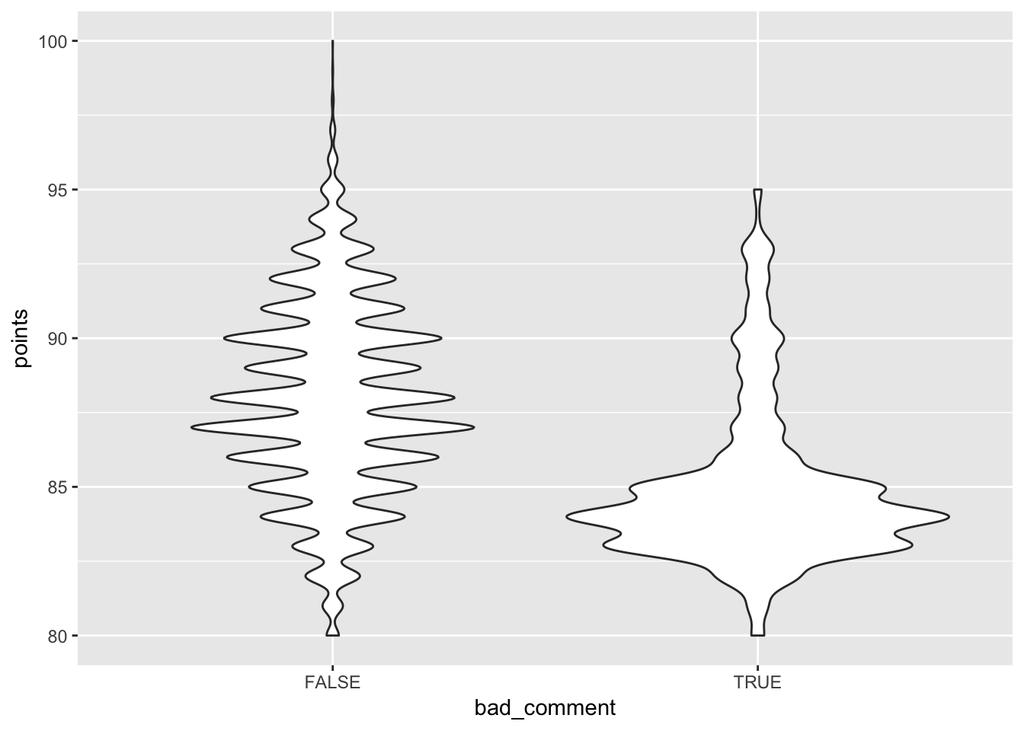

Here FALSE violin is the ones without the bad comments or more specifically “bad_comments = FALSE” so is a good_comment :). Whereas TRUE violin is the bad comments (bad_comments=TRUE). Here we can clearly see that bad_comments=TRUE violin has a belly in the lower points while its head sharpens and decreases towards the upper points (max to point 95).

##### Complicated approach

Now lets do a complicated sentiment analysis on “description” feature. This time we will create a new feature by reading “description” feature and will appoint a “sentiment” score to the review.

```
## # A tibble: 3 x 2
##   sentiment avg_point
##       <dbl>     <dbl>
## 1        -8      84
## 2        -7      83.9
## 3        -6      85.3
```

```
## # A tibble: 3 x 2
##   sentiment avg_point
##       <dbl>     <dbl>
## 1        10      91.2
## 2        11      92.6
## 3        12      92.4
```

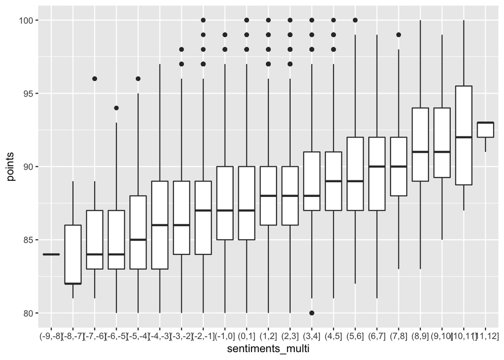

Above we can clearly see that whenever sentiment point increase, point of the review also increases! The logic behind is simple actually: Whenever a positive word is read from the description of the review, then that review gains 1 point for positive and whenever a negative word is read then 1 point for negative. At the end we just create a new feature as “sentiment” via the following equation: positive - negative.

### Filling NA values in “price” column with linear regression and added new features

##### First find a good correlation with price and other features

First correlation result is: price ~ point  
Second correlation result is: price ~ point + sentiment  
Third correlation result is: price ~ point + bad_comment + sentiment Fourt correalatiın result is: price ~ point + bad_comment + negative + positive

```
## [1] 0.4598599
```

```
## [1] 0.3633088
```

```
## [1] 0.3633635
```

```
## [1] 0.406543
```

##### Filling the missing values

```
##
## Call:
## lm(formula = log(price + 1) ~ points + bad_comment + sentiment,
##     data = data)
##
## Coefficients:
##     (Intercept)           points  bad_commentTRUE        sentiment
##        -7.88374          0.12812         -0.10037         -0.03914
```

Now we have filled our NA values. Note that we want to predict a positive value. Therefore linear regression might not be the best model however we have found a trick and used “log” in the formula to avoid negative predictions. When we actually want to fetch the prediction we then “exponentiate” the “logged” result

### Now that we have improved our dataset, we can move on to clustering wines.

#### Clustering with dendogram

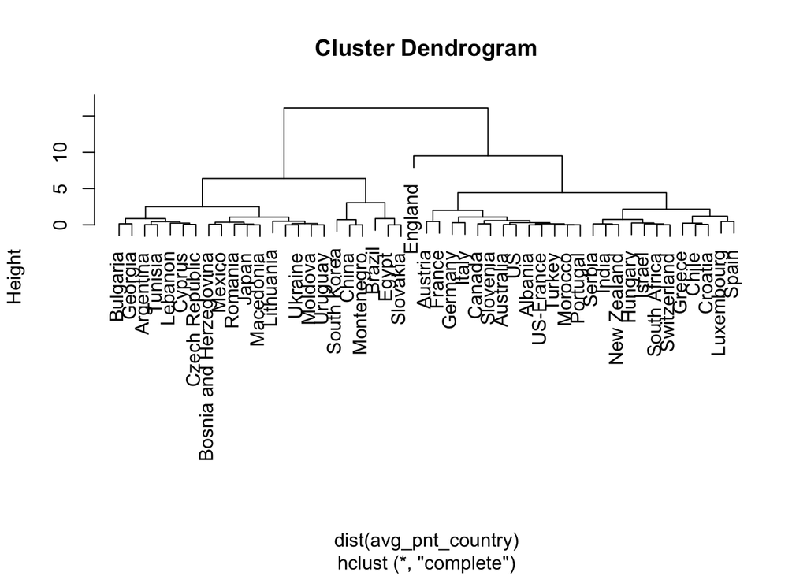

Above we can see which countries are similar according to their wine review points.

#### Clustering with k-means

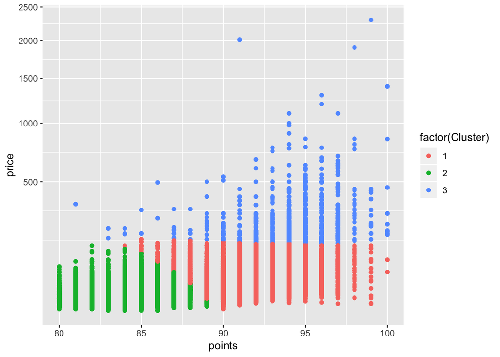

Above gives us a great insight. There are 3 wines categories: 1-Cheap and good 2-Cheap and not so good 3-Expensive